# Register Nurses (RNs) Data Analysis Report

2022-05-04

```r
knitr::opts_chunk$set(echo = TRUE)
library(tidytuesdayR)
library(dplyr)
```

```r
library(ggplot2)
library(forcats)
library(tidyverse)
#Turning "off" scientific notation because of the large numbers in the data set
options(scipen = 100)
```

# Let’s load and preview our data

```r
tuesdata <- tidytuesdayR::tt_load(2021, week = 41)
```

```
## --- Compiling #TidyTuesday Information for 2021-10-05 ----
```

```
## --- There is 1 file available ---
```

```
## --- Starting Download ---
```

```
## --- Download complete ---
```

```r
nurses <- na.omit(tuesdata$nurses)

#Subsetting the data and ensuring there are no NA values
nurses <-
  nurses %>%
  select(c(1, 2, 3, 5, 6, 7)) %>%
  filter_at(vars(State, Year, `Total Employed RN`, `Hourly Wage Avg`, `Hourly Wage Median`, `Annual Salary Avg`), all_vars(!is.na(.)))

head(nurses)
```

```
## # A tibble: 6 x 6
##   State       Year `Total Employed RN` `Hourly Wage Avg` `Hourly Wage Median`
##   <chr>      <dbl>               <dbl>             <dbl>                <dbl>
## 1 Alabama     2020               48850              29.0                 28.2
## 2 Alaska      2020                6240              45.8                 45.2
## 3 Arizona     2020               55520              38.6                 38.0
## 4 Arkansas    2020               25300              30.6                 30.0
## 5 California  2020              307060              58.0                 56.9
## 6 Colorado    2020               52330              37.4                 36.8
## # ... with 1 more variable: `Annual Salary Avg` <dbl>
```

## Looking at the data we are working with, it would be intersting to know the relationship between of the Annual Salary Avg by year:

### Let’s first investigate how many Year groups we are looking at

```r
unique(nurses$Year)
```

```
##  [1] 2020 2018 2015 2013 2012 2019 2010 2016 2017 2011 2014
```

```r
str(nurses)
```

```
## tibble [592 x 6] (S3: tbl_df/tbl/data.frame)
##  $ State             : chr [1:592] "Alabama" "Alaska" "Arizona" "Arkansas" ...
##  $ Year              : num [1:592] 2020 2020 2020 2020 2020 2020 2020 2020 2020 2020 ...
##  $ Total Employed RN : num [1:592] 48850 6240 55520 25300 307060 ...
##  $ Hourly Wage Avg   : num [1:592] 29 45.8 38.6 30.6 58 ...
##  $ Hourly Wage Median: num [1:592] 28.2 45.2 38 30 56.9 ...
##  $ Annual Salary Avg : num [1:592] 60230 95270 80380 63640 120560 ...
##  - attr(*, "na.action")= 'omit' Named int [1:650] 325 326 327 328 329 330 331 332 333 334 ...
##   ..- attr(*, "names")= chr [1:650] "325" "326" "327" "328" ...
```

It appears that there is data going back 11 years from 2010 - 2020. It also appears that the variable Year is treated as a number rather than a category or factor.

### We have to make sure each year is treated as a factor rather than a continous number if we are to get separate categories by year.

## Annual Salary Average for RNs by Year (Boxplot)

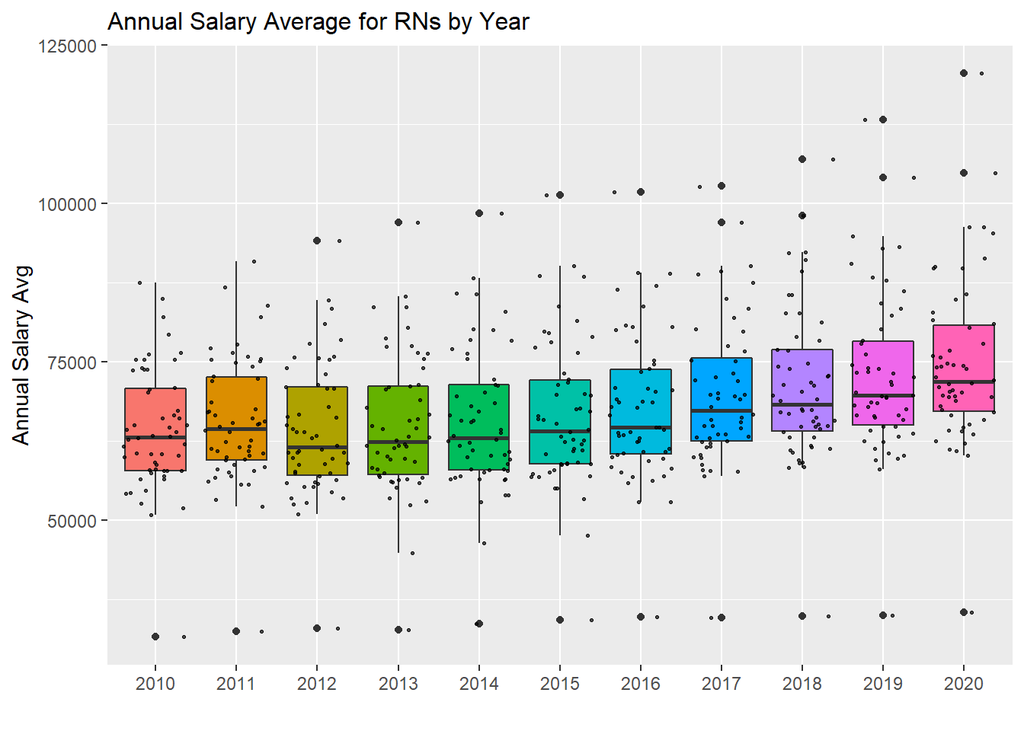

```r
nurses %>%
  ggplot(aes(x = factor(Year), y = `Annual Salary Avg`, fill = factor(Year))) +
    geom_boxplot() +
    geom_jitter(color="black", size=0.5, alpha=0.7) +
    theme(
      legend.position="none",
      plot.title = element_text(size=12)
    ) +
    ggtitle("Annual Salary Average for RNs by Year") +
    xlab("")
```

## Total Number of Employed RNs by Year (Boxplot)

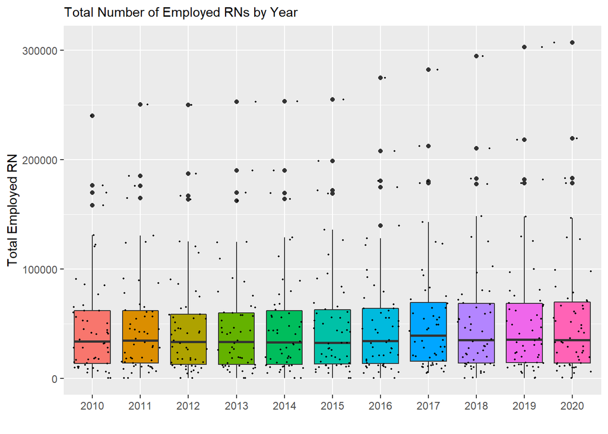

```r
nurses %>%
  ggplot(aes(x = factor(Year), y = `Total Employed RN`, fill = factor(Year))) +
    geom_boxplot() +
    geom_jitter(color="black", size=0.4, alpha=0.9) +
    theme(
      legend.position="none",
      plot.title = element_text(size=11)
    ) +
    ggtitle("Total Number of Employed RNs by Year") +
    xlab("")
```

There does not seem to be a change in employment over the years suggesting that the number of RNs in the field probably do not impact the relationship we are observing with annual salary average over time. Regardless, it would be prudent to observe this relationship directly.

## Total Employed RNs by Annual Salary Average (scatterplot)

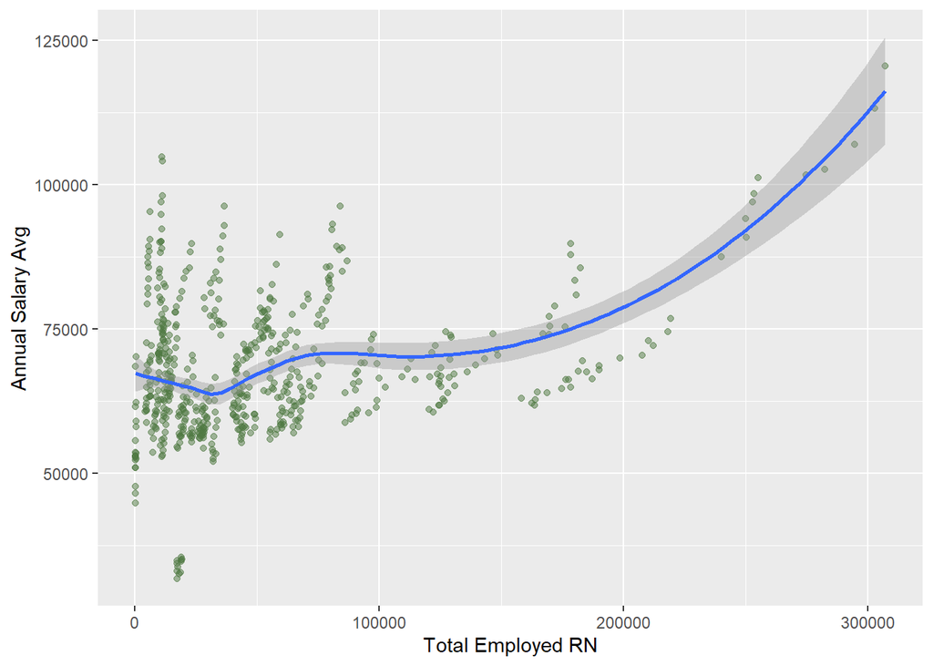

```r
nurses %>%
  ggplot(aes(x = `Total Employed RN`, y = `Annual Salary Avg`)) +
  geom_point(color = "#4F7942", alpha = .5) +
  geom_smooth()
```

Considering the great degree of overlapp, it would make interpretation easier if log transform our X-variable.

## Total Employed RNs by Annual Salary Average (scatterplot) |Log Transformed|

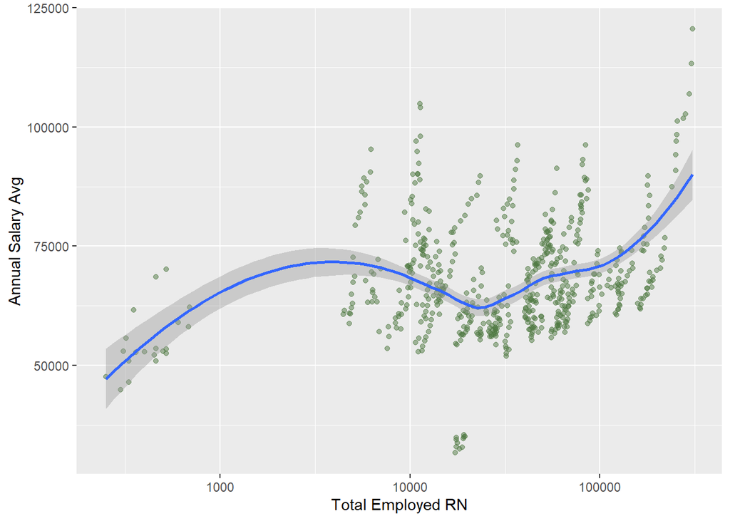

```r
nurses %>%
  ggplot(aes(x = `Total Employed RN`, y = `Annual Salary Avg`)) +
  geom_point(color = "#4F7942", alpha = .5) +
  geom_smooth() +
  scale_x_continuous(
    trans = "log10"
  )
```

We can see that the outliers of total number of employed nurses below 1,000 and annual salary average below 50,000 appears to make it difficult to interpret the relationship between these two variables. Let’s go ahead and drop those values by subsetting.

## Total Employed RNs by Annual Salary Average (scatterplot) |Log Transformed| Outliers Dropped|

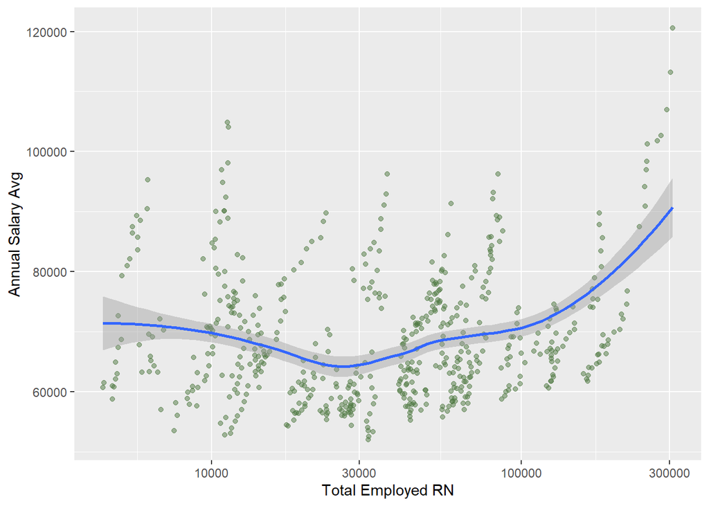

```r
nursesSub<- subset(nurses,`Total Employed RN`>1000)

nursesSub<- subset(nursesSub,`Annual Salary Avg`>50000)

nursesSub %>%
  ggplot(aes(x = `Total Employed RN`, y = `Annual Salary Avg`)) +
  geom_point(color = "#4F7942", alpha = .5) +
  geom_smooth() +
  scale_x_continuous(
    trans = "log10"
  )
```

After transforming the data and removing the outliers, we are finally able to observe the relationship! There appears to be a slight dip in annual salary average when there are about 30,000 RNs employed and a positive relationship between the two variables once we get into 100,000+ total number of employed RNs. Further investigation is warranted.